# Different Expression Analysis with DEseq2

An important task of bulk rna-seq analysis is the different expression , which we can perform with omicverse. For different expression analysis, ov change the `gene_id` to `gene_name` of matrix first.

Now we can use `PyDEseq2` to perform DESeq2 analysis like R

Paper: [PyDESeq2: a python package for bulk RNA-seq differential expression analysis](https://www.biorxiv.org/content/10.1101/2022.12.14.520412v1)

Code: https://github.com/owkin/PyDESeq2

Colab_Reproducibility：https://colab.research.google.com/drive/1fZS-v0zdIYkXrEoIAM1X5kPoZVfVvY5h?usp=sharing

```python
import omicverse as ov
ov.utils.ov_plot_set()
```

import omicverse as ov ov.utils.ov_plot_set()

```
/Users/fernandozeng/miniforge3/envs/scbasset/lib/python3.8/site-packages/phate/__init__.py
```

Note that this dataset has not been processed in any way and is only exported by `featureCounts`, and Sequence alignment was performed from the genome file of CRCm39

```python
data=ov.utils.read('https://raw.githubusercontent.com/Starlitnightly/Pyomic/master/sample/counts.txt',index_col=0,header=1)
#replace the columns `.bam` to ``
data.columns=[i.split('/')[-1].replace('.bam','') for i in data.columns]
data.head()
```

data=ov.utils.read('https://raw.githubusercontent.com/Starlitnightly/Pyomic/master/sample/counts.txt',index_col=0,header=1) #replace the columns `.bam` to `` data.columns=[i.split('/')[-1].replace('.bam','') for i in data.columns] data.head()

| Geneid | 1--1 | 1--2 | 2--1 | 2--2 | 3--1 | 3--2 | 4--1 | 4--2 | 4-3 | 4-4 | Blank-1 | Blank-2 |
| --- | --- | --- | --- | --- | --- | --- | --- | --- | --- | --- | --- | --- |
| ENSMUSG00000102628 | 0 | 0 | 0 | 0 | 5 | 0 | 0 | 0 | 0 | 0 | 0 | 9 |
| ENSMUSG00000100595 | 0 | 0 | 0 | 0 | 0 | 0 | 0 | 0 | 0 | 0 | 0 | 0 |
| ENSMUSG00000097426 | 5 | 0 | 0 | 0 | 0 | 0 | 0 | 1 | 0 | 0 | 0 | 0 |
| ENSMUSG00000104478 | 0 | 0 | 0 | 0 | 0 | 0 | 0 | 0 | 0 | 0 | 0 | 0 |
| ENSMUSG00000104385 | 0 | 0 | 0 | 0 | 0 | 0 | 0 | 0 | 0 | 0 | 0 | 0 |

## ID mapping

We performed the gene_id mapping by the mapping pair file `GRCm39` downloaded before.

```python
ov.utils.download_geneid_annotation_pair()
```

ov.utils.download_geneid_annotation_pair()

```python
data=ov.bulk.Matrix_ID_mapping(data,'genesets/pair_GRCm39.tsv')
data.head()
```

data=ov.bulk.Matrix_ID_mapping(data,'genesets/pair_GRCm39.tsv') data.head()

|  | 1--1 | 1--2 | 2--1 | 2--2 | 3--1 | 3--2 | 4--1 | 4--2 | 4-3 | 4-4 | Blank-1 | Blank-2 |
| --- | --- | --- | --- | --- | --- | --- | --- | --- | --- | --- | --- | --- |
| Gm14845 | 115 | 116 | 84 | 86 | 133 | 170 | 130 | 105 | 91 | 127 | 124 | 99 |
| Hdc | 97 | 579 | 123 | 172 | 571 | 119 | 106 | 28 | 217 | 156 | 2 | 51 |
| H2bu2 | 60 | 59 | 58 | 22 | 71 | 73 | 75 | 138 | 55 | 38 | 18 | 53 |
| Gm6693 | 0 | 0 | 0 | 0 | 0 | 0 | 0 | 0 | 0 | 0 | 0 | 0 |
| Rnd3 | 2423 | 2289 | 1996 | 1750 | 2304 | 2669 | 2952 | 2109 | 2030 | 2026 | 875 | 2555 |

## Different expression analysis with ov

We can do differential expression analysis very simply by ov, simply by providing an expression matrix. To run DEG, we simply need to:

- Read the raw count by featureCount or any other qualify methods.
- Create an ov DEseq object.

```python
dds=ov.bulk.pyDEG(data)
```

dds=ov.bulk.pyDEG(data)

We notes that the gene_name mapping before exist some duplicates, we will process the duplicate indexes to retain only the highest expressed genes

```python
dds.drop_duplicates_index()
print('... drop_duplicates_index success')
```

dds.drop_duplicates_index() print('... drop_duplicates_index success')

```
... drop_duplicates_index success
```

Now we can calculate the different expression gene from matrix, we need to input the treatment and control groups

```python
treatment_groups=['4-3','4-4']
control_groups=['1--1','1--2']
result=dds.deg_analysis(treatment_groups,control_groups,method='DEseq2')
```

treatment_groups=['4-3','4-4'] control_groups=['1--1','1--2'] result=dds.deg_analysis(treatment_groups,control_groups,method='DEseq2')

```
Fitting size factors...
... done in 0.00 seconds.

Fitting dispersions...
... done in 1.59 seconds.

Fitting dispersion trend curve...
... done in 2.82 seconds.

logres_prior=1.1538905878789707, sigma_prior=0.25
Fitting MAP dispersions...
... done in 1.57 seconds.

Fitting LFCs...
... done in 1.27 seconds.

Refitting 0 outliers.

Running Wald tests...
... done in 1.33 seconds.

Log2 fold change & Wald test p-value: condition Treatment vs Control
```

[output not shown]

One important thing is that we do not filter out low expression genes when processing DEGs, and in future versions I will consider building in the corresponding processing.

```python
print(result.shape)
result=result.loc[result['log2(BaseMean)']>1]
print(result.shape)
```

print(result.shape) result=result.loc[result['log2(BaseMean)']>1] print(result.shape)

```
(54504, 14)
(23377, 14)
```

We also need to set the threshold of Foldchange, we prepare a method named `foldchange_set` to finish. This function automatically calculates the appropriate threshold based on the log2FC distribution, but you can also enter it manually.

```python
# -1 means automatically calculates
dds.foldchange_set(fc_threshold=-1,
                   pval_threshold=0.05,
                   logp_max=10)
```

# -1 means automatically calculates dds.foldchange_set(fc_threshold=-1, pval_threshold=0.05, logp_max=10)

```
... Fold change threshold: 1.6248531033651643
```

## Visualize the DEG result and specific genes

To visualize the DEG result, we use `plot_volcano` to do it. This fuction can visualize the gene interested or high different expression genes. There are some parameters you need to input:

- title: The title of volcano
- figsize: The size of figure
- plot_genes: The genes you interested
- plot_genes_num: If you don't have interested genes, you can auto plot it.

```python
dds.plot_volcano(title='DEG Analysis',figsize=(4,4),
                 plot_genes_num=8,plot_genes_fontsize=12,)
```

dds.plot_volcano(title='DEG Analysis',figsize=(4,4), plot_genes_num=8,plot_genes_fontsize=12,)

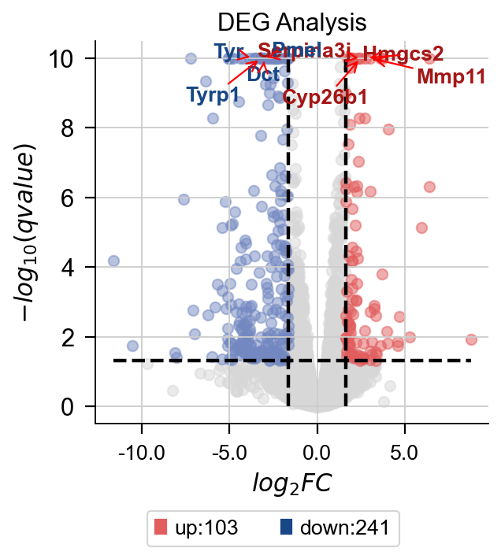

To visualize the specific genes, we only need to use the `dds.plot_boxplot` function to finish it.

```python
dds.plot_boxplot(genes=['Ckap2','Lef1'],treatment_groups=treatment_groups,
                control_groups=control_groups,figsize=(2,3),fontsize=12,
                 legend_bbox=(2,0.55))
```

dds.plot_boxplot(genes=['Ckap2','Lef1'],treatment_groups=treatment_groups, control_groups=control_groups,figsize=(2,3),fontsize=12, legend_bbox=(2,0.55))

```
(<Figure size 160x240 with 1 Axes>,
 <Axes: title={'center': 'Gene Expression'}>)
```

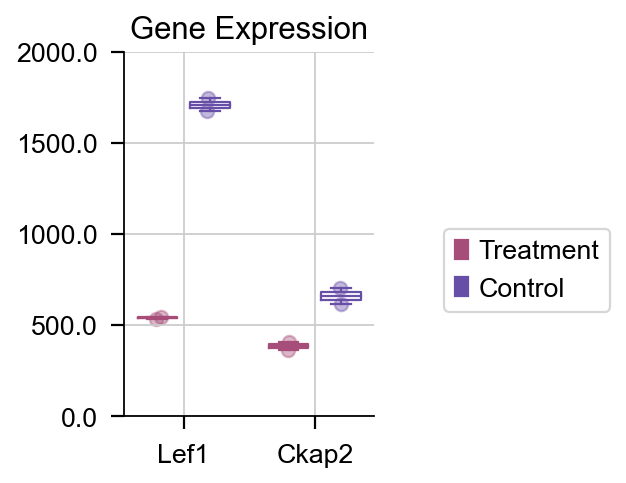

```python
dds.plot_boxplot(genes=['Ckap2'],treatment_groups=treatment_groups,
                control_groups=control_groups,figsize=(2,3),fontsize=12,
                 legend_bbox=(2,0.55))
```

dds.plot_boxplot(genes=['Ckap2'],treatment_groups=treatment_groups, control_groups=control_groups,figsize=(2,3),fontsize=12, legend_bbox=(2,0.55))

```
(<Figure size 160x240 with 1 Axes>,
 <Axes: title={'center': 'Gene Expression'}>)
```

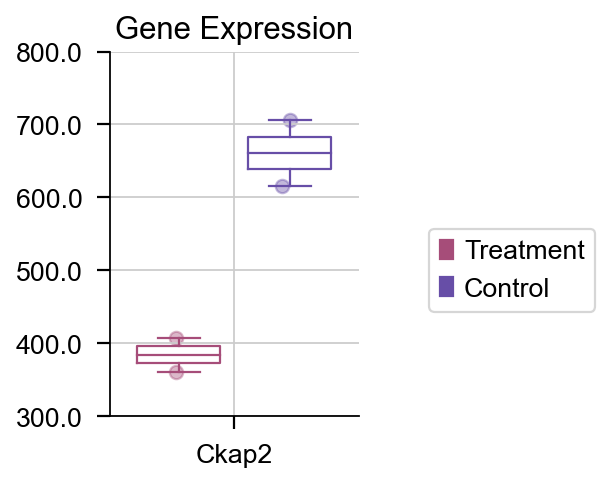

## Pathway enrichment analysis by Pyomic

Here we use the `gseapy` package, which included the GSEA analysis and Enrichment. We have optimised the output of the package and given some better looking graph drawing functions

```python
ov.utils.download_pathway_database()
```

ov.utils.download_pathway_database()

```
......Pathway Geneset download start: GO_Biological_Process_2021
......Loading dataset from genesets/GO_Biological_Process_2021.txt
......Pathway Geneset download start: GO_Cellular_Component_2021
......Loading dataset from genesets/GO_Cellular_Component_2021.txt
......Pathway Geneset download start: GO_Molecular_Function_2021
......Loading dataset from genesets/GO_Molecular_Function_2021.txt
......Pathway Geneset download start: WikiPathway_2021_Human
......Loading dataset from genesets/WikiPathway_2021_Human.txt
......Pathway Geneset download start: WikiPathways_2019_Mouse
......Loading dataset from genesets/WikiPathways_2019_Mouse.txt
......Pathway Geneset download start: Reactome_2022
......Loading dataset from genesets/Reactome_2022.txt
......Pathway Geneset download finished!
......Other Genesets can be dowload in `https://maayanlab.cloud/Enrichr/#libraries`
```

```python
pathway_dict=ov.utils.geneset_prepare('genesets/WikiPathways_2019_Mouse.txt',organism='Mouse')
```

pathway_dict=ov.utils.geneset_prepare('genesets/WikiPathways_2019_Mouse.txt',organism='Mouse')

To perform the GSEA analysis, we need to ranking the genes at first. Using `dds.ranking2gsea` can obtain a ranking gene's matrix sorted by -log10(padj).

$Metric=\frac{-log_{10}(padj)}{sign(log2FC)}$

```python
rnk=dds.ranking2gsea()
```

rnk=dds.ranking2gsea()

We used `ov.bulk.pyGSEA` to construst a GSEA object to perform enrichment.

```python
gsea_obj=ov.bulk.pyGSEA(rnk,pathway_dict)
```

gsea_obj=ov.bulk.pyGSEA(rnk,pathway_dict)

```python
enrich_res=gsea_obj.enrichment()
```

enrich_res=gsea_obj.enrichment()

```
2023-05-18 03:12:10,455 Input gene rankings contains NA values(gene name and ranking value), drop them all!
```

The results are stored in the `enrich_res` attribute.

```python
gsea_obj.enrich_res.head()
```

gsea_obj.enrich_res.head()

| Term | es | nes | pval | fdr | geneset_size | matched_size | genes | ledge_genes | logp | logc | num | fraction | Term | P-value |
| --- | --- | --- | --- | --- | --- | --- | --- | --- | --- | --- | --- | --- | --- | --- |
| Complement and Coagulation Cascades WP449 | 0.732116 | 2.140070 | 0.0 | 0.000000 | 62 | 56 | Cfd;Masp1;F2r;C4b;Hc;Cfh;F7;F12;Pros1;Serping1... | Cfd;Masp1;F2r;C4b;Hc;Cfh;F7;F12;Pros1;Serping1... | 9.210340 | 2.140070 | 56 | 0.903226 | Complement and Coagulation Cascades WP449 | 0.000000 |
| Matrix Metalloproteinases WP441 | 0.879498 | 2.397240 | 0.0 | 0.000000 | 29 | 27 | Mmp11;Mmp14;Mmp3;Mmp12;Timp4;Timp1;Mmp28;Mmp9;... | Mmp11;Mmp14;Mmp3;Mmp12;Timp4;Timp1;Mmp28;Mmp9;... | 9.210340 | 2.397240 | 27 | 0.931034 | Matrix Metalloproteinases WP441 | 0.000000 |
| TYROBP Causal Network WP3625 | 0.786372 | 2.358131 | 0.0 | 0.000000 | 58 | 57 | Itgax;Itgb2;Rgs1;Gpx1;Lhfpl2;Tcirg1;Cxcl16;Cd3... | Itgax;Itgb2;Rgs1;Gpx1;Lhfpl2;Tcirg1;Cxcl16;Cd3... | 9.210340 | 2.358131 | 57 | 0.982759 | TYROBP Causal Network WP3625 | 0.000000 |
| PPAR signaling pathway WP2316 | 0.681572 | 2.074737 | 0.0 | 0.003011 | 81 | 69 | Hmgcs2;Pck1;Slc27a1;Scd3;Acox3;Acsbg1;Scd1;Ang... | Hmgcs2;Pck1;Slc27a1;Scd3;Acox3;Acsbg1;Scd1;Ang... | 5.772960 | 2.074737 | 69 | 0.851852 | PPAR signaling pathway WP2316 | 0.003011 |
| Metapathway biotransformation WP1251 | 0.643937 | 1.991519 | 0.0 | 0.012042 | 141 | 120 | Cyp26b1;Cyp2e1;Fmo2;Gpx1;Cyp4b1;Cyp11a1;Mgst2;... | Cyp26b1;Cyp2e1;Fmo2;Gpx1;Cyp4b1;Cyp11a1;Mgst2;... | 4.411073 | 1.991519 | 120 | 0.851064 | Metapathway biotransformation WP1251 | 0.012042 |

To visualize the enrichment, we use `plot_enrichment` to do.

- num: The number of enriched terms to plot. Default is 10.
- node_size: A list of integers defining the size of nodes in the plot. Default is [5,10,15].
- cax_loc: The location of the colorbar on the plot. Default is 2.
- cax_fontsize: The fontsize of the colorbar label. Default is 12.
- fig_title: The title of the plot. Default is an empty string.
- fig_xlabel: The label of the x-axis. Default is 'Fractions of genes'.
- figsize: The size of the plot. Default is (2,4).
- cmap: The colormap to use for the plot. Default is 'YlGnBu'.

```python
gsea_obj.plot_enrichment(num=10,node_size=[10,20,30],
                        cax_fontsize=12,
                        fig_title='Wiki Pathway Enrichment',fig_xlabel='Fractions of genes',
                        figsize=(2,4),cmap='YlGnBu',
                        text_knock=2,text_maxsize=30,
                        cax_loc=[2.5, 0.45, 0.5, 0.02],
                          bbox_to_anchor_used=(-0.25, -13),node_diameter=10,)
```

gsea_obj.plot_enrichment(num=10,node_size=[10,20,30], cax_fontsize=12, fig_title='Wiki Pathway Enrichment',fig_xlabel='Fractions of genes', figsize=(2,4),cmap='YlGnBu', text_knock=2,text_maxsize=30, cax_loc=[2.5, 0.45, 0.5, 0.02], bbox_to_anchor_used=(-0.25, -13),node_diameter=10,)

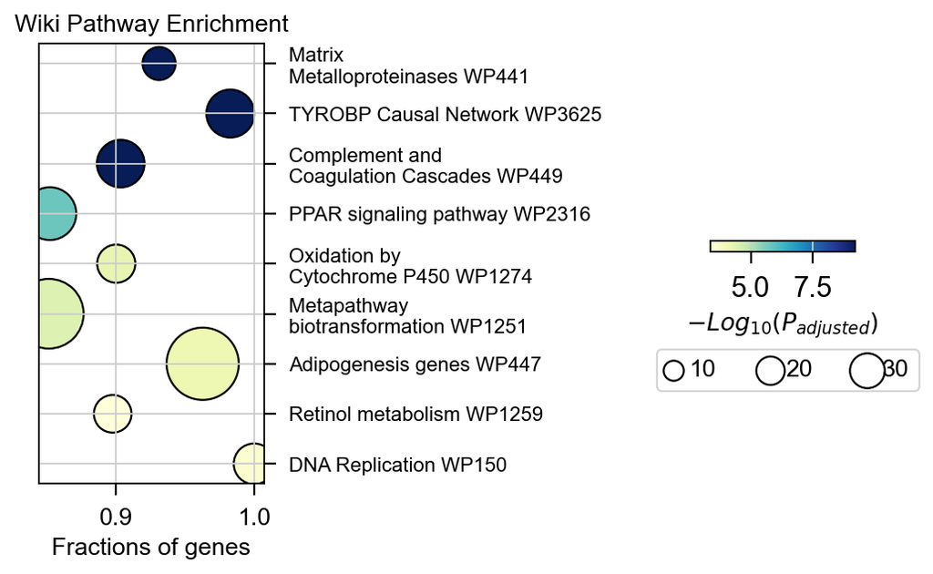

Not only the basic analysis, pyGSEA also help us to visualize the term with Ranked and Enrichment Score.

We can select the number of term to plot, which stored in `gsea_obj.enrich_res.index`, the `0` is `Complement and Coagulation Cascades WP449` and the `1` is `Matrix Metalloproteinases WP441`

```python
gsea_obj.enrich_res.index[:5]
```

gsea_obj.enrich_res.index[:5]

```
Index(['Complement and Coagulation Cascades WP449',
       'Matrix Metalloproteinases WP441', 'TYROBP Causal Network WP3625',
       'PPAR signaling pathway WP2316',
       'Metapathway biotransformation WP1251'],
      dtype='object', name='Term')
```

We can set the `gene_set_title` to change the title of GSEA plot

```python
fig=gsea_obj.plot_gsea(term_num=1,
                  gene_set_title='Matrix Metalloproteinases',
                  figsize=(3,4),
                  cmap='RdBu_r',
                  title_fontsize=14,
                  title_y=0.95)
```

fig=gsea_obj.plot_gsea(term_num=1, gene_set_title='Matrix Metalloproteinases', figsize=(3,4), cmap='RdBu_r', title_fontsize=14, title_y=0.95)

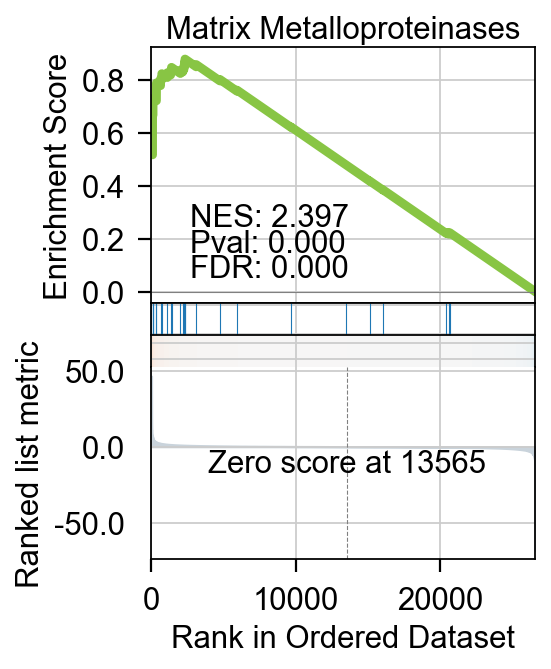